# act_report

## RESULTS FROM DATA ANALYSIS AND VISUALIZATION- WeRateDogs

Dogs! Lovable creatures aren’t they! I analyzed the WeRateDogs twitter data set containing information on tweets about dogs, and the results are quite informative.

Three insights are captured from the analysis:

1. What are 3 the most popular dog names?
2. Which dog classes are most common?
3. What is the most common dog type in the p2 column?

The data set after cleaning contained 2073 records of data for 21 different columns of features. I analyzed the features in the above-mentioned bullets to arrive at the desired answers. Each insight is expounded and visualized in the following sections:

1. What are the 3 most popular dog names? The `value_counts()` function was extremely helping in the analyses. To obtain the 3 most popular dog names in our data sets, we used the `value_counts()` function to order the dog names in descending order of frequency. The following were obtained Charlie 11 Oliver 10 Tucker 10 Lucy 10 Cooper 10 Penny 10

Placing Charlie on top of the list, and **Oliver, Tucker, Lucy, Cooper** and **Penny** next. Below is a bar chart of the top 3 dog names, selecting Tucker and Oliver from the runners up.

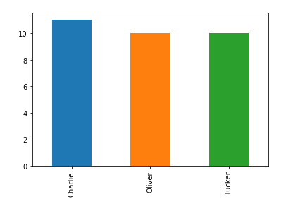

1. Which dog classes are most common? For this analysis, we get our results from analyzing the `dogtionary` column on the data set. Applying `value_counts()` again provides us with the following order: pupper 210 doggo 67 puppo 23 mixed 13 floofer 7

Placing **pupper** at first place, followed by **doggo, puppo, mixed** and then **floofer**. The mixed breeds fall in 2 breeds (e.g., doggopuppo)

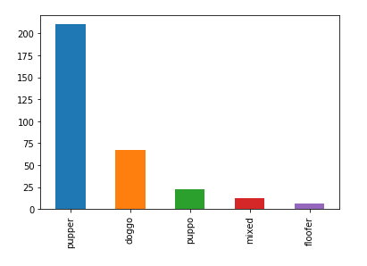

1. Which is the most common dog type in the p2 column? The `p2` column contains the algorithm’s second most likely prediction. The descending order of frequency of this list is as follows: labrador_retriever 104 golden_retriever 92 cardigan 74 chihuahua 44 pomeranian 42

These represent the top 5 most likely predictions, with the **labrador_retriever** atop the list with 104, and the **golden_retreiver** next with 92.

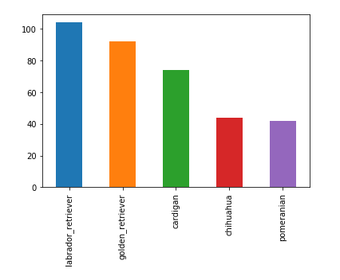